# GH1025343_AI_and_Application_Zineb_EJJABIRI_

[figure not shown]

## Introduction

My role as a data science consultant was to apply data analytics to help the business of online retailers of women's clothes understand what customers say. The provided client has so far provided us with a full dataset comprising customer reviews, ratings, and feedback on the clothing products the company sells, crucial to making sense of customer attitude and preference.

Reviews are the big gun used by e-commerce to enhance consumer satisfaction and also to expand their product options in order to raise revenue. But extracting any useful information from enormous amounts of unstructured data is complex. This is where data science comes in. I would like to analyze this data to get some patterns, trends, and insights necessary for our client to make well-informed decisions on customer service, marketing, and product design.

In this, I will walk the client through the data exploration process, clean up the dataset for accuracy, and also answer some key business questions that have been so instrumental in improving customer experience and driving sales.

# Importing Packages

```python
import pandas as pd
import numpy as np
import matplotlib.pyplot as plt
import seaborn as sns
from wordcloud import WordCloud
import warnings
warnings.filterwarnings('ignore')
```

# Data Preprocessing and cleaning

```python
df = pd.read_csv("/content/archive.zip")

print(df.shape)
print()
df.head()
df.columns
df.info()

print("\nThe number of nulls are: " + str(df.isna().sum().sum()))

df_copy = df.copy()

df_copy.drop(["Unnamed: 0", "Clothing ID"], axis=1, inplace=True)

duplicate_rows = df_copy[df_copy.duplicated()]
print("\nNumber of duplicates: ", duplicate_rows.shape)

df_copy = df_copy.drop_duplicates(inplace=False)
duplicate_rows = df_copy[df_copy.duplicated()]
print("\nNumber of duplicates after deleting: ", duplicate_rows.shape)

print("\nPrinting before cleaning:")
display(df_copy.head())

print("The null breakdown before cleaning the dataset:")
print(df_copy.isna().sum())

df_copy ['Title'].fillna('No Title', inplace=True)
df_copy ['Review Text'].fillna('NaN', inplace=True)
df_copy.dropna(inplace=True)

print("\nPrinting after cleaning:")
display(df_copy.head())

print("The null breakdown after cleaning the dataset:")
print(df_copy.isna().sum())
```

```
(23486, 11)

<class 'pandas.core.frame.DataFrame'>
RangeIndex: 23486 entries, 0 to 23485
Data columns (total 11 columns):
 #   Column                   Non-Null Count  Dtype
---  ------                   --------------  -----
 0   Unnamed: 0               23486 non-null  int64
 1   Clothing ID              23486 non-null  int64
 2   Age                      23486 non-null  int64
 3   Title                    19676 non-null  object
 4   Review Text              22641 non-null  object
 5   Rating                   23486 non-null  int64
 6   Recommended IND          23486 non-null  int64
 7   Positive Feedback Count  23486 non-null  int64
 8   Division Name            23472 non-null  object
 9   Department Name          23472 non-null  object
 10  Class Name               23472 non-null  object
dtypes: int64(6), object(5)
memory usage: 2.0+ MB

The number of nulls are: 4697

Number of duplicates:  (232, 9)

Number of duplicates after deleting:  (0, 9)

Printing before cleaning:
```

|  | Age | Title | Review Text | Rating | Recommended IND | Positive Feedback Count | Division Name | Department Name | Class Name |
| --- | --- | --- | --- | --- | --- | --- | --- | --- | --- |
| 0 | 33 | NaN | Absolutely wonderful - silky and sexy and comf... | 4 | 1 | 0 | Initmates | Intimate | Intimates |
| 1 | 34 | NaN | Love this dress! it's sooo pretty. i happene... | 5 | 1 | 4 | General | Dresses | Dresses |
| 2 | 60 | Some major design flaws | I had such high hopes for this dress and reall... | 3 | 0 | 0 | General | Dresses | Dresses |
| 3 | 50 | My favorite buy! | I love, love, love this jumpsuit. it's fun, fl... | 5 | 1 | 0 | General Petite | Bottoms | Pants |
| 4 | 47 | Flattering shirt | This shirt is very flattering to all due to th... | 5 | 1 | 6 | General | Tops | Blouses |

```
The null breakdown before cleaning the dataset:
Age                           0
Title                      3579
Review Text                 615
Rating                        0
Recommended IND               0
Positive Feedback Count       0
Division Name                14
Department Name              14
Class Name                   14
dtype: int64

Printing after cleaning:
```

|  | Age | Title | Review Text | Rating | Recommended IND | Positive Feedback Count | Division Name | Department Name | Class Name |
| --- | --- | --- | --- | --- | --- | --- | --- | --- | --- |
| 0 | 33 | No Title | Absolutely wonderful - silky and sexy and comf... | 4 | 1 | 0 | Initmates | Intimate | Intimates |
| 1 | 34 | No Title | Love this dress! it's sooo pretty. i happene... | 5 | 1 | 4 | General | Dresses | Dresses |
| 2 | 60 | Some major design flaws | I had such high hopes for this dress and reall... | 3 | 0 | 0 | General | Dresses | Dresses |
| 3 | 50 | My favorite buy! | I love, love, love this jumpsuit. it's fun, fl... | 5 | 1 | 0 | General Petite | Bottoms | Pants |
| 4 | 47 | Flattering shirt | This shirt is very flattering to all due to th... | 5 | 1 | 6 | General | Tops | Blouses |

```
The null breakdown after cleaning the dataset:
Age                        0
Title                      0
Review Text                0
Rating                     0
Recommended IND            0
Positive Feedback Count    0
Division Name              0
Department Name            0
Class Name                 0
dtype: int64
```

**Explanation :** First we are gonna start with printing the data fram shape and rows, checking the numbers of nulls, copying the data, dropping unnecessary columns, checking for duplicates, and handling nulls

# Exploratory Data Analysis :

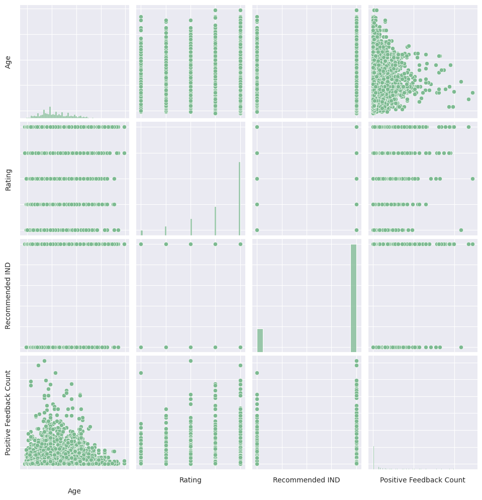

```python
numerical_columns = list(df_copy.loc[:,['Age','Rating','Recommended IND','Positive Feedback Count']])
sample_size = min (len(df_copy), 50000)
sampled_data = df_copy. sample(sample_size, random_state=42)

sns.set_palette('crest')
sns.set_style('darkgrid')

dnp = sns.pairplot(sampled_data. loc[:, numerical_columns])

dnp.set(xticklabels=[], yticklabels=[])

dnp.axes[0][0].set_ylabel(numerical_columns[0], fontsize=10)

dnp.axes[-1][0].set_xlabel(numerical_columns[0], fontsize=10)

dnp.axes[-1][0].xaxis.labelpad = 20

dnp.axes[-1][-1].yaxis.labelpad = 20
```

**Explanation :** we are gonna start with changing :

- sns-set_palette to sns.set_palette
- sns-pairplot to sns.pairplot
- dnp-set to dnp.set
- dnp-axes to dnp.axes
- numerical-_columns to numerical_columns

```python
df["Rating"].value_counts()
```

| Rating | count |
| --- | --- |
| 5 | 13131 |
| 4 | 5077 |
| 3 | 2871 |
| 2 | 1565 |
| 1 | 842 |

**dtype:** int64

**Explanation :** Breakdown the Rating

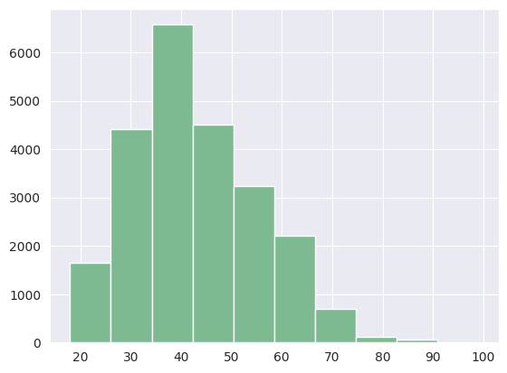

```python
df["Age"].hist()
```

**Explanation :** I used a histogram to visualize the distribution of the "Age"

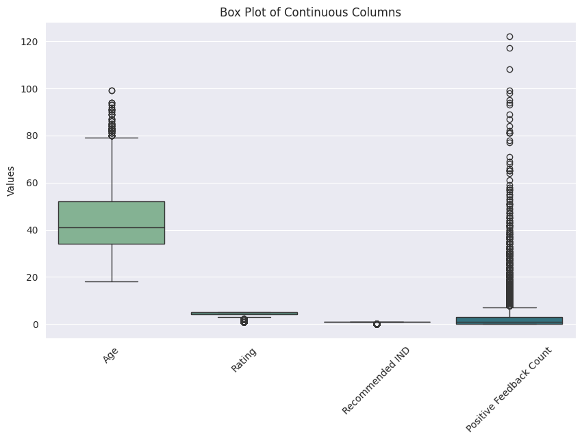

|  | count | mean | std | min | 25% | 50% | 75% | max |
| --- | --- | --- | --- | --- | --- | --- | --- | --- |
| Age | 23240.0 | 43.236704 | 12.310359 | 18.0 | 34.0 | 41.0 | 52.0 | 99.0 |
| Rating | 23240.0 | 4.188769 | 1.113138 | 1.0 | 4.0 | 5.0 | 5.0 | 5.0 |
| Recommended IND | 23240.0 | 0.820482 | 0.383794 | 0.0 | 1.0 | 1.0 | 1.0 | 1.0 |
| Positive Feedback Count | 23240.0 | 2.562478 | 5.726332 | 0.0 | 0.0 | 1.0 | 3.0 | 122.0 |

```python
continuous_columns = ['Age', 'Rating', 'Recommended IND','Positive Feedback Count' ]

plt.figure(figsize=(10, 6))
sns.boxplot(data=df_copy[continuous_columns])


plt.title('Box Plot of Continuous Columns')
plt.ylabel('Values')
plt.xticks(rotation=45)

plt.show()

df_copy.describe().T
```

**Explanation :** Creating a boxplot to compare the columns side by side, in order to have a visually assess the distribution, spread, and potential outliers in the data.

```python
print("Number of Unique Division:", df_copy['Division Name'].nunique())
print("Names of Divisions:", df_copy['Division Name'].unique())
```

```
Number of Unique Division: 3
Names of Divisions: ['Initmates' 'General' 'General Petite']
```

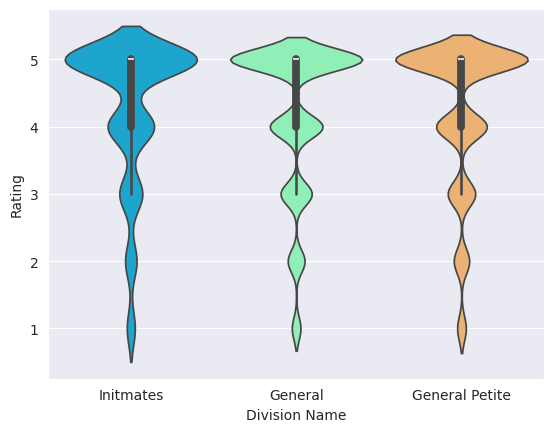

```python
sns.violinplot(x="Division Name", y="Rating", data=df_copy,palette='rainbow')
```

**Explanation :** Violin plot to visualise relationship between Division Name and Rating

# Business Insights

**QUESTION 1** : What are the most common clothing items reviewed?

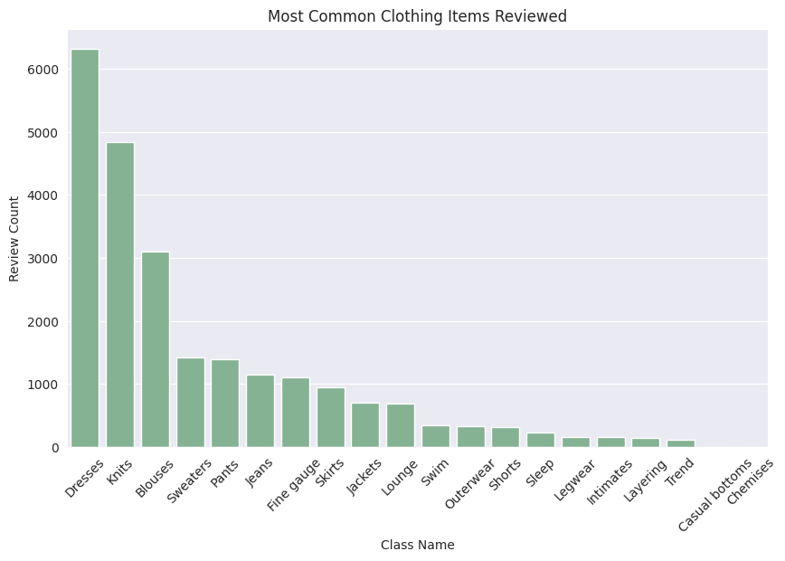

```python
if 'Class Name' in df:

    product_counts = df['Class Name'].value_counts().reset_index()

    product_counts.columns = ['Class Name', 'Review Count']

    plt.figure(figsize=(10,6))
    sns.barplot(x='Class Name', y='Review Count', data=product_counts)
    plt.xticks(rotation=45)
    plt.title('Most Common Clothing Items Reviewed')
plt.show()
```

**Interpretaion of Question 1 :**

The most reviewed clothing items, the Dresses category ranks the first, followed in order by the Knits and Blouses. This means that dresses are very much in demand among the clients, probably because they can be worn on different occasions. Knits and blouses, which emerged second and third, show that these segments of the consumer’s wardrobe are also important, but less so than dresses.

**QUESTION 2 :** What are the overall customer sentiment and rating trends?

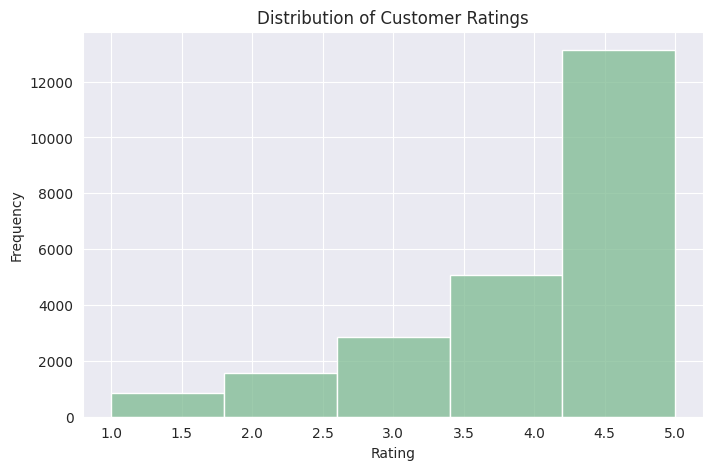

```
The average customer rating is 4.20 out of 5.
```

```python
average_rating = df['Rating'].mean()

plt.figure(figsize=(8,5))
sns.histplot(df['Rating'], bins=5, kde=False)
plt.title("Distribution of Customer Ratings")
plt.xlabel("Rating")
plt.ylabel("Frequency")
plt.show()

print(f"The average customer rating is {average_rating:.2f} out of 5.")
```

**Interpretaion of Question 2 :**

Based on the data, the average customer rating is 4.20 out of 5. This suggests a generally positive reception from customers, indicating a high level of satisfaction with the cloths

**QUESTION 3 :** How do positive and negative reviews differ in terms of word usage?

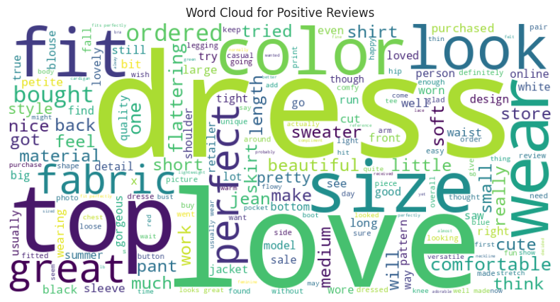

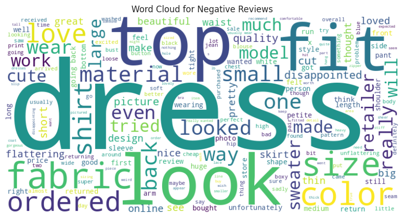

```python
positive_reviews = df[df['Rating'] >= 4]['Review Text'].dropna()
negative_reviews = df[df['Rating'] <= 2]['Review Text'].dropna()

def generate_wordcloud(text, title):
    wordcloud = WordCloud(width=800, height=400, background_color='white').generate(" ".join(text))
    plt.figure(figsize=(10, 5))
    plt.imshow(wordcloud, interpolation='bilinear')
    plt.axis("off")
    plt.title(title)
    plt.show()

generate_wordcloud(positive_reviews, "Word Cloud for Positive Reviews")
generate_wordcloud(negative_reviews, "Word Cloud for Negative Reviews")
```

**Interpretaion of Question 3:** we start our code by definding the positive and negative reviews, and then we generate word clouds for positive and negative reviews.

- For Positive words : we have on top, Love, Dresses, top, color, size, great,wear, look, fit
- For Negative words : we have, Dress, look, top, fit, size, made, small, return

**Question 4** : What is the most popular product category by Division?

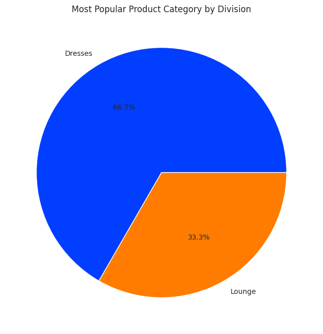

```python
def most_popular_class_by_division(df):
    division_class = df.groupby('Division Name')['Class Name'].agg(lambda x: x.value_counts().index[0])
    return division_class

division_class = most_popular_class_by_division(df)

keys, data = np.unique(division_class, return_counts=True)

palette_color = sns.color_palette('bright')

plt.figure(figsize=(8, 8))
plt.pie(data, labels=keys, colors=palette_color, autopct='%.1f%%')

plt.title("Most Popular Product Category by Division")
plt.show()
```

**Interpretaion of Question 4:**

Dresses dominate as the most popular category, accounting for 66.7% of divisions, while Lounge products hold 33.3%, reflecting a secondary but notable demand.

**Question 5** : What factors influence high vs. low ratings?

```python
high_ratings = df[df['Rating'] >= 4]
low_ratings = df[df['Rating'] <= 2]

high_helpfulness = high_ratings['Positive Feedback Count'].mean()
low_helpfulness = low_ratings['Positive Feedback Count'].mean()

print(f"Average helpfulness votes for high ratings: {high_helpfulness:.2f}")
print(f"Average helpfulness votes for low ratings: {low_helpfulness:.2f}")
```

```
Average helpfulness votes for high ratings: 2.33
Average helpfulness votes for low ratings: 3.37
```

**Interpretaion of Question 5:** The customers might find negative reviews (low ratings) more helpful or informative, possibly because they focus more on potential issues or problems, leading others to give them more helpfulness (realistic) vote that other customers want to be aware of before making a purchase decision.

**Question 6** : What is the correlation between review length and rating?

```
The correlation between review length and rating is -0.07.
```

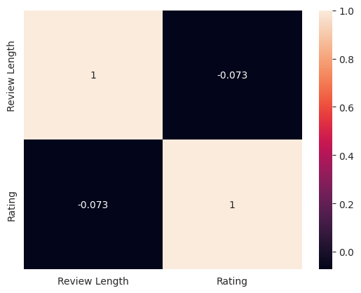

```python
df['Review Length'] = df['Review Text'].apply(lambda x: len(str(x)))

correlation = df[['Review Length', 'Rating']].corr().loc['Review Length', 'Rating']
print(f"The correlation between review length and rating is {correlation:.2f}.")

sns.heatmap(df[['Review Length', 'Rating']].corr(), annot= True)
plt.show()
```

**Interpretaion of Question 6:** The correlation between review length and rating is -0.07, which indicates a very weak negative correlation. This means that, in general, as the length of a review increases, the rating slightly tends to decrease, but the relationship is so small that it may not be practically significant.

**Question 7** : Do product reviews differ based on customer age group?

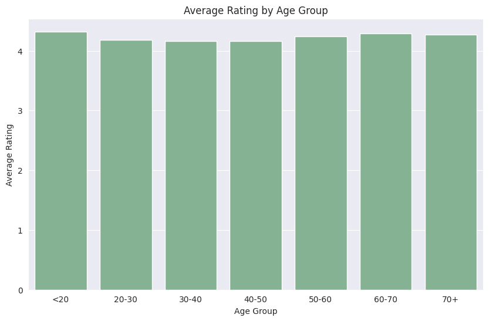

```python
bins = [0, 20, 30, 40, 50, 60, 70, 100]
labels = ['<20', '20-30', '30-40', '40-50', '50-60', '60-70', '70+']
df['Age Group'] = pd.cut(df['Age'], bins=bins, labels=labels)

average_rating_by_age = df.groupby('Age Group')['Rating'].mean()

plt.figure(figsize=(10,6))
sns.barplot(x=average_rating_by_age.index, y=average_rating_by_age.values)
plt.title('Average Rating by Age Group')
plt.xlabel('Age Group')
plt.ylabel('Average Rating')
plt.show()
```

**Interpretaion of Question 7:** The product reviews does not really differ based on the age group, on the graph we can similarities.

**Question 8** : What are the Average Rating Trends for Each Department ?

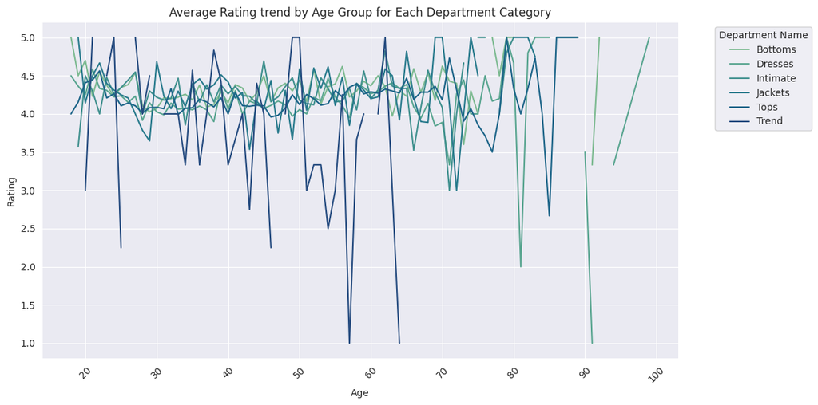

```python
avg_rating_by_age_class = df_copy.groupby(['Age', 'Department Name'])['Rating'].mean().unstack()

plt.figure(figsize=(10,6))
avg_rating_by_age_class.plot(kind='line', figsize=(12, 6))
plt.title('Average Rating trend by Age Group for Each Department Category')
plt.xlabel('Age')
plt.ylabel('Rating')
plt.xticks(rotation=45)
plt.legend(title="Department Name", bbox_to_anchor=(1.05, 1), loc='upper left')
plt.tight_layout()
plt.show()
```

## Conclusion :

The analysis has shown, in the final instance, that data gave insight into the behavior and preference of customers, which were actionable strategies that the e-commerce company could take to improve both the products they were offering and customers' experiences. The consideration of such patterns in making decisions about improvements to be done and marketing strategies would also consider the length and rating of reviews as important. Therefore, the knowledge of the weak correlation between length review and rating will have the company focus on other factors that might be more influential. Besides, the realization that negative reviews get more helpfulness votes insinuates that proactive handling of customer concerns boosts brand trust. Ultimately, these will drive more intuitive decisions to further improve customer satisfaction and overall sales.

The link to the data :

[Kaggle Data set](https://www.kaggle.com/code/saiprasadpadala/starter-women-s-e-commerce-clothing-72789f05-0/notebook)

```python
%%shell
jupyter nbconvert --to html /
```